# Sieanna Ruiz: (Project 1) Horton General Hospital

### Lets investigate:

Was the number of patients transferred from the Emergency Room to Critical Care at Horton General Hospital unusually high during December 2003–February 2004 compared to what would be expected based on normal hospital activity?

When I look at the Benjamin Geen case, I see how deeply connected it is to data science. The central question referred above high—depends on how data is collected, analyzed, and interpreted. As someone interested in data science, I recognize that statistical tools can help determine whether an observed pattern is genuinely abnormal or simply random variation. This case reminds me that misinterpreting small datasets or ignoring context can have serious real-world consequences, showing why careful, evidence-based data analysis is essential in healthcare and legal decision-making.

# Lets start!

```python
# Import libraries
import pandas as pd
import numpy as np
import matplotlib.pyplot as plt
import seaborn as sns
from sklearn.linear_model import LinearRegression
from sklearn.model_selection import train_test_split
from sklearn.metrics import r2_score, mean_squared_error
```

```python
# Set up plotting style
plt.style.use('default')
plt.rcParams['figure.figsize'] = (10, 6)
plt.rcParams['font.size'] = 12
```

```python
# Connect to Google Drive
from google.colab import drive
drive.mount('/content/drive')
```

# Loading and preparing our data

```python
# Load the Horton Hospital dataset from an uploaded file
# Make sure you have uploaded the file to your Colab session
file_path = '/content/drive/My Drive/ColabNotebooks/Project_1/HortonGeneralHospital.csv'
data = pd.read_csv(file_path)

print(f"Dataset shape: {data.shape}")
display(data.head())
```

```
Dataset shape: (139, 7)
```

|  | Unnamed: 0 | Cardio | Resp | Hypo | Adm | year | month |
| --- | --- | --- | --- | --- | --- | --- | --- |
| 0 | 1 | 1 | 0 | 0 | 413 | 1999 | 11 |
| 1 | 2 | 1 | 0 | 0 | 443 | 1999 | 12 |
| 2 | 3 | 1 | 0 | 0 | 378 | 2000 | 1 |
| 3 | 4 | 0 | 0 | 0 | 385 | 2000 | 2 |
| 4 | 5 | 1 | 0 | 0 | 388 | 2000 | 3 |

```python
# Clean up the column names
data = data.drop(columns=['Unnamed: 0'])
data.columns = ['Cardio-Resp', 'Respiratory', 'Hypoglycaemic', 'Admissions', 'Year','Month']
```

```python
# Find total amount of patients transfered to critcal care
totaltranfers = data['Cardio-Resp']+data['Respiratory']+data['Hypoglycaemic']
data['Tranfers']= totaltranfers
print(f"The total amount of ER admissions to critical care from this data set is: {data['Tranfers'].sum()}")
print("Note: This data was taken from 1999 to 2011")
```

```
The total amount of ER admissions to critical care from this data set is: 167
Note: This data was taken from 1999 to 2011
```

```python
# Group amount of Tranfers by year
yearly_transfer = data.groupby('Year')['Tranfers'].sum()
yearly_transfer = yearly_transfer.reset_index()
yearly_transfer = yearly_transfer.sort_values('Year')
print(yearly_transfer)
```

```
    Year  Tranfers
0   1999         2
1   2000        12
2   2001        11
3   2002        19
4   2003        19
5   2004        19
6   2005        12
7   2006        17
8   2007         7
9   2008        14
10  2009        18
11  2010        12
12  2011         5
```

Most tranfers are in the double digit range except for the years: 1999, 2007, and 2011 with single digit trranfers.

# Show a table with tranfer rates

- This table can identify which numbers look outlying to the eye
- Starting off simple but with basic info about this data set in a clearer form

```python
# Calculate the yearly transfer rate by grouping by year
yearly_transfer_rate = data.groupby('Year')[['Tranfers', 'Admissions']].sum()
yearly_transfer_rate['TransferRate'] = (yearly_transfer_rate['Tranfers'] / yearly_transfer_rate['Admissions']) * 100

# Display the yearly transfer rate
display(yearly_transfer_rate)
```

| Year | Tranfers | Admissions | TransferRate |
| --- | --- | --- | --- |
| 1999 | 2 | 856 | 0.233645 |
| 2000 | 12 | 4927 | 0.243556 |
| 2001 | 11 | 5422 | 0.202877 |
| 2002 | 19 | 6047 | 0.314205 |
| 2003 | 19 | 6795 | 0.279617 |
| 2004 | 19 | 7786 | 0.244028 |
| 2005 | 12 | 6830 | 0.175695 |
| 2006 | 17 | 6472 | 0.262670 |
| 2007 | 7 | 6523 | 0.107313 |
| 2008 | 14 | 6348 | 0.220542 |
| 2009 | 18 | 7005 | 0.256959 |
| 2010 | 12 | 6907 | 0.173737 |
| 2011 | 5 | 2445 | 0.204499 |

In the Ben Geen case the highlighted years were 2003-2004. From this table we can see that there is a high amount of transfers in 2002, 2003, and 2004. We can also see there was a high amount of tranfers in 2006 and 2009. Looking at the tranfer rates, there are all relativty around the same average except for some years with much lower rates like 2007.

# Visualize with scatter plot

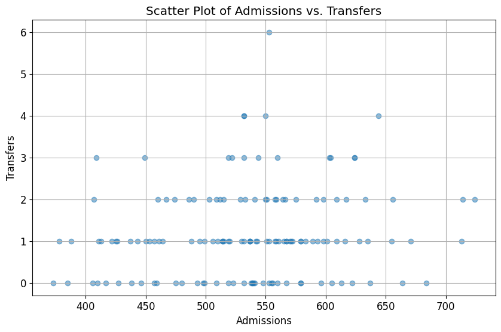

```python
# Create a scatter plot of adimissions vs. transfers
plt.figure(figsize=(10, 6))
plt.scatter(data['Admissions'], data['Tranfers'], alpha=0.5)
plt.xlabel('Admissions')
plt.ylabel('Transfers')
plt.title('Scatter Plot of Admissions vs. Transfers')
plt.grid(True)
plt.show()
```

```python
# Calculate correlation
coorelation = data['Admissions'].corr(data['Tranfers'])
print(f"The correlation between Admissions and Transfers is: {coorelation:.3f}")
```

```
The correlation between Admissions and Transfers is: 0.151
```

The correlation coefficient of 0.151 indicates a very weak positive linear relationship between the number of admissions and the number of transfers. In simpler terms, there is not a strong tendency for transfers to increase significantly as admissions increase, or vice versa. The low number of transfers relative to the high number of admissions contributes to this low correlation because the variability in transfers is limited, making it difficult to detect a strong linear relationship with the much larger and more variable number of admissions.

```python
# Lets look at the Transfer rate just in its own column
yearly_transfer_rate = yearly_transfer_rate.reset_index()
yearly_transfer_rate = yearly_transfer_rate.set_index('Year')
yearly_transfer_rate_ts = yearly_transfer_rate['TransferRate']
display(yearly_transfer_rate_ts)
```

| Year | TransferRate |
| --- | --- |
| 1999 | 0.233645 |
| 2000 | 0.243556 |
| 2001 | 0.202877 |
| 2002 | 0.314205 |
| 2003 | 0.279617 |
| 2004 | 0.244028 |
| 2005 | 0.175695 |
| 2006 | 0.262670 |
| 2007 | 0.107313 |
| 2008 | 0.220542 |
| 2009 | 0.256959 |
| 2010 | 0.173737 |
| 2011 | 0.204499 |

**dtype:** float64

Based on the yearly transfer rate table, most transfer rates are around the same average, except for some years with much lower rates like 2007. The years 2002, 2003, and 2004 show a high amount of transfers, as do 2006 and 2009

# Lets use a time series plot to visually see what patterns are reconiziable

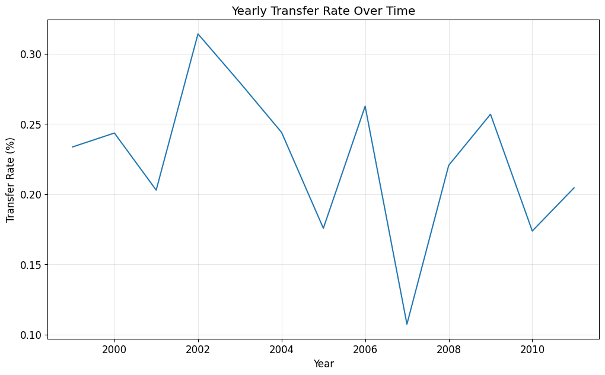

```python
plt.figure(figsize=(12, 7))
yearly_transfer_rate_ts.plot(kind='line')
plt.xlabel('Year')
plt.ylabel('Transfer Rate (%)')
plt.title('Yearly Transfer Rate Over Time')
plt.grid(True, alpha=0.3)
plt.show()
```

# Regresion Pattern?

Split the data into training (Jan 2002 - Nov 2003) and testing (Dec 2003 - Mar 2004) sets, train a model to predict 'Transfers' from 'Admissions', and evaluate the model's performance.

## Filter the data for training and testing

Select the data for the training period (Jan 2002 - Nov 2003) and the testing period (Dec 2003 - Mar 2004).

## Lets clean up and organize our data

Combine "Year" and "Month" columns to create a date column, convert it to datetime objects, and then filter the data for the specified (year) training and testing periods.

```python
# Combine 'Year' and 'Month' to create a date column and convert to datetime objects
data['date'] = data['Year'].astype(str) + '-' + data['Month'].astype(str).str.zfill(2)
data['date'] = pd.to_datetime(data['date'])

# Define the training and testing periods
train_start_date = '2002-01-01'
train_end_date = '2003-11-30'
test_start_date = '2003-12-01'
test_end_date = '2004-03-31'
```

```python
# Filter the data for the specified periods
train_data = data[(data['date'] >= train_start_date) & (data['date'] <= train_end_date)].copy()
test_data = data[(data['date'] >= test_start_date) & (data['date'] <= test_end_date)].copy()
```

# Selecting which features we are trying to represent

### What's our independent/dependent varibles?

Define "Admissions" as the feature (independent variable) and "Tranfers" as the target variable (dependent variable) using the filtered data.

## Prepare training and testing sets

### First:

Separate the filtered data into training and testing sets based on the specified date ranges.

```python
# Define the feature (X) and target (y) variables for the training data.
X = train_data['Admissions'].values.reshape(-1, 1)
y = train_data['Tranfers']
```

```python
# Define the feature (X) and target (y) variables for the test data.
X_test = test_data['Admissions'].values.reshape(-1, 1)
y_test = test_data['Tranfers']
```

## Choose and train models to find any informaiton with stats

### Let's see if regression is a good model fit

Use a regression model and train it on the training data.

- Lets see if linear regression can show us what

```python
# Use linearRegression as a blueprint

linear_model = LinearRegression()
linear_model.fit(X, y)
```

```
LinearRegression()
```

## Evaluate the model

Assess the model's performance using appropriate regression metrics R-squared, Mean Squared Error on the testing data.

Use the trained models to make predictions on the test data and calculate the evaluation metrics.

```python
y_pred_lr = linear_model.predict(X_test)
mse_lr = mean_squared_error(y_test, y_pred_lr)
r2_lr = r2_score(y_test, y_pred_lr)

print(f"Linear Regression Model:")
print(f"  Mean Squared Error (MSE): {mse_lr:.3f}")
print(f"  R-squared (R2): {r2_lr:.3f}")
```

```
Linear Regression Model:
  Mean Squared Error (MSE): 6.609
  R-squared (R2): -1.034
```

## Make predictions

Use the trained model to make predictions on the testing data.

# Prediction Time!

Use the trained linear regression model to predict the transfers on the test data and storing the predictions in the specified variables.

```python
y_pred_linear = linear_model.predict(X_test)
```

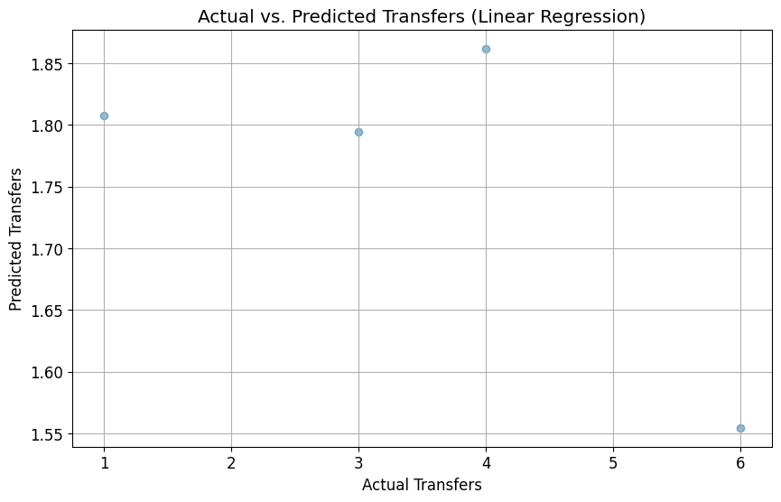

```python
# Plot and show the prediciton
plt.figure(figsize=(10, 6))
plt.scatter(y_test, y_pred_linear, alpha=0.5)
plt.xlabel('Actual Transfers')
plt.ylabel('Predicted Transfers')
plt.title('Actual vs. Predicted Transfers (Linear Regression)')
plt.grid(True)
plt.show()
```

## Summary:

### Next Steps

- Further analysis should explore additional features or more complex models to improve the prediction of "Transfers".
- Since regression was a poor model lets try a classification model to further explore some key points about "Transfers"

# Feature Modeling

Classify periods into high/low transfer periods, highlight when transfer periods were higher by month and year, and visualize the results.

## Define high/low transfer periods

### Looking at years 2002-2004

```python
# Combine 'Year' and 'Month' to create a date column and convert to datetime objects
data['date'] = data['Year'].astype(str) + '-' + data['Month'].astype(str).str.zfill(2)
data['date'] = pd.to_datetime(data['date'])

# Define the training and testing periods
train_start_date = '2002-01-01'
train_end_date = '2003-11-30'
test_start_date = '2003-12-01'
test_end_date = '2004-03-31'

# Filter the data for the specified periods
train_data = data[(data['date'] >= train_start_date) & (data['date'] <= train_end_date)].copy()
test_data = data[(data['date'] >= test_start_date) & (data['date'] <= test_end_date)].copy()

# Display the first 5 stats for train and test set
display(train_data.head())
display(test_data.head())
```

|  | Cardio-Resp | Respiratory | Hypoglycaemic | Admissions | Year | Month | Tranfers | date |
| --- | --- | --- | --- | --- | --- | --- | --- | --- |
| 26 | 0 | 0 | 0 | 459 | 2002 | 1 | 0 | 2002-01-01 |
| 27 | 1 | 0 | 0 | 461 | 2002 | 2 | 1 | 2002-02-01 |
| 28 | 1 | 0 | 0 | 488 | 2002 | 3 | 1 | 2002-03-01 |
| 29 | 2 | 0 | 0 | 486 | 2002 | 4 | 2 | 2002-04-01 |
| 30 | 2 | 0 | 0 | 515 | 2002 | 5 | 2 | 2002-05-01 |

|  | Cardio-Resp | Respiratory | Hypoglycaemic | Admissions | Year | Month | Tranfers | date |
| --- | --- | --- | --- | --- | --- | --- | --- | --- |
| 49 | 0 | 4 | 0 | 644 | 2003 | 12 | 4 | 2003-12-01 |
| 50 | 1 | 2 | 0 | 624 | 2004 | 1 | 3 | 2004-01-01 |
| 51 | 3 | 2 | 1 | 553 | 2004 | 2 | 6 | 2004-02-01 |
| 52 | 1 | 0 | 0 | 628 | 2004 | 3 | 1 | 2004-03-01 |

# Determine a threshold to classify periods as "high" or "low" transfer periods.

Calculate the mean of the 'Tranfers' column in the (data) DataFrame and store it in a variable named "transfer_threshold".

```python
transfer_threshold = data['Tranfers'].mean()
print(f"The mean transfer rate is: {transfer_threshold:.3f}")
```

```
The mean transfer rate is: 1.201
```

## Create a classification column

Add a new column to the data that indicates whether a period is "high" or "low" based on the defined threshold.

```python
data['TransferCategory'] = data['Tranfers'].apply(lambda x: 'High' if x > transfer_threshold else 'Low')
display(data.head())
```

|  | Cardio-Resp | Respiratory | Hypoglycaemic | Admissions | Year | Month | Tranfers | date | TransferCategory |
| --- | --- | --- | --- | --- | --- | --- | --- | --- | --- |
| 0 | 1 | 0 | 0 | 413 | 1999 | 11 | 1 | 1999-11-01 | Low |
| 1 | 1 | 0 | 0 | 443 | 1999 | 12 | 1 | 1999-12-01 | Low |
| 2 | 1 | 0 | 0 | 378 | 2000 | 1 | 1 | 2000-01-01 | Low |
| 3 | 0 | 0 | 0 | 385 | 2000 | 2 | 0 | 2000-02-01 | Low |
| 4 | 1 | 0 | 0 | 388 | 2000 | 3 | 1 | 2000-03-01 | Low |

The code data['Tranfers'].apply(lambda x: 'High' if x > transfer_threshold else 'Low') checks each individual transfer value against the thresold. Only if a row's "Transfer" value is strickly greater than 1.201 will it be classified as "High". The rows you're seeing at the head of the DataFrame happen to have transfer values that fall below or equal to the threshold.

## Analyze high transfer periods by month and year

```python
# Group the data by year and month count the occurences of high transfer periods
high_transfer_periods = data[data['TransferCategory'] == 'High'].groupby(['Year', 'Month']).size().reset_index(name='HighTransferCount')
display(high_transfer_periods)
```

|  | Year | Month | HighTransferCount |
| --- | --- | --- | --- |
| 0 | 2000 | 5 | 1 |
| 1 | 2000 | 9 | 1 |
| 2 | 2001 | 4 | 1 |
| 3 | 2001 | 7 | 1 |
| 4 | 2001 | 11 | 1 |
| 5 | 2002 | 4 | 1 |
| 6 | 2002 | 5 | 1 |
| 7 | 2002 | 8 | 1 |
| 8 | 2002 | 9 | 1 |
| 9 | 2002 | 11 | 1 |
| 10 | 2002 | 12 | 1 |
| 11 | 2003 | 2 | 1 |
| 12 | 2003 | 3 | 1 |
| 13 | 2003 | 8 | 1 |
| 14 | 2003 | 10 | 1 |
| 15 | 2003 | 12 | 1 |
| 16 | 2004 | 1 | 1 |
| 17 | 2004 | 2 | 1 |
| 18 | 2004 | 7 | 1 |
| 19 | 2004 | 9 | 1 |
| 20 | 2005 | 1 | 1 |
| 21 | 2005 | 4 | 1 |
| 22 | 2005 | 9 | 1 |
| 23 | 2006 | 1 | 1 |
| 24 | 2006 | 2 | 1 |
| 25 | 2006 | 6 | 1 |
| 26 | 2006 | 8 | 1 |
| 27 | 2006 | 9 | 1 |
| 28 | 2006 | 11 | 1 |
| 29 | 2007 | 5 | 1 |
| 30 | 2008 | 2 | 1 |
| 31 | 2008 | 5 | 1 |
| 32 | 2008 | 9 | 1 |
| 33 | 2008 | 11 | 1 |
| 34 | 2009 | 1 | 1 |
| 35 | 2009 | 3 | 1 |
| 36 | 2009 | 5 | 1 |
| 37 | 2009 | 6 | 1 |
| 38 | 2009 | 7 | 1 |
| 39 | 2009 | 8 | 1 |
| 40 | 2010 | 5 | 1 |
| 41 | 2010 | 7 | 1 |
| 42 | 2010 | 11 | 1 |
| 43 | 2011 | 3 | 1 |

# Visualize high transfer periods

Create visualizations heatmap and box plot to highlight when high transfer periods occurred by month and year.

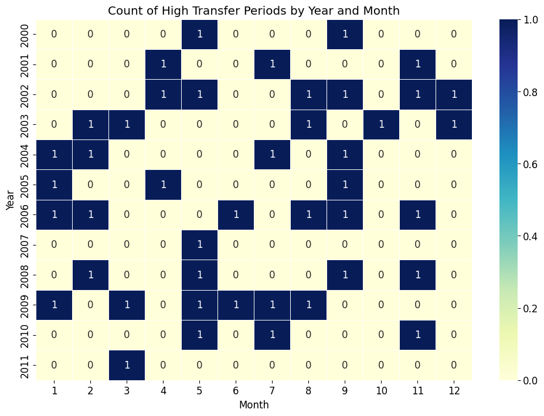

```python
# Create a pivot table from the high_transfer_periods DataFrame and then generate a heatmap to visualize the count of high transfer periods by year and month.
pivot_table = high_transfer_periods.pivot_table(index='Year', columns='Month', values='HighTransferCount').fillna(0)

plt.figure(figsize=(12, 8))
sns.heatmap(pivot_table, cmap='YlGnBu', annot=True, fmt='g', linewidths=.5)
plt.title('Count of High Transfer Periods by Year and Month')
plt.show()
```

## Summary:

### Next Steps

- Further analysis could explore the factors contributing to the peaks in high transfer periods observed in certain months or years.
- The classification could be refined by exploring alternative thresholding methods beyond the mean, such as using percentiles or box plots

## Identify peak periods

Clearly identify the specific months and years that show a significantly higher number of high transfer periods based on the previous heatmap.

```python
# Get the top months and years with the highest high transfer counts
stacked_pivot_table = pivot_table.stack().reset_index(name='HighTransferCount')
sorted_high_transfer_periods = stacked_pivot_table.sort_values(by='HighTransferCount', ascending=False)

print("Top 5 months and years with the highest high transfer periods:")
display(sorted_high_transfer_periods.head())
```

```
Top 5 months and years with the highest high transfer periods:
```

|  | Year | Month | HighTransferCount |
| --- | --- | --- | --- |
| 4 | 2000 | 5 | 1.0 |
| 8 | 2000 | 9 | 1.0 |
| 15 | 2001 | 4 | 1.0 |
| 37 | 2003 | 2 | 1.0 |
| 38 | 2003 | 3 | 1.0 |

## Explore internal factors

Analyze if there are any internal factors within the dataset that correlate with these peak periods.

Filter the data to include only the identified peak periods and calculate the average transfers for 'Cardio-Resp', 'Respiratory', and 'Hypoglycaemic' for these periods and for the entire dataset.

```python
peak_periods = [(2000, 5), (2000, 9), (2001, 4), (2003, 2), (2003, 3)]

peak_periods_data = data[data.apply(lambda row: (row['Year'], row['Month']) in peak_periods, axis=1)].copy()

avg_transfers_peak = peak_periods_data[['Cardio-Resp', 'Respiratory', 'Hypoglycaemic']].mean()
avg_transfers_overall = data[['Cardio-Resp', 'Respiratory', 'Hypoglycaemic']].mean()

print("Average transfers during peak periods:")
print(avg_transfers_peak)
print("\nOverall average transfers:")
print(avg_transfers_overall)
```

```
Average transfers during peak periods:
Cardio-Resp      1.8
Respiratory      0.2
Hypoglycaemic    0.6
dtype: float64

Overall average transfers:
Cardio-Resp      0.863309
Respiratory      0.251799
Hypoglycaemic    0.086331
dtype: float64
```

Durning the identified peack tranfer periods (like May 2000, September 2000, April 2001, February 2003, and Match 2003), we observed that the average number of "Cardio-Resp" transfers was substantially higher (1.8) compared to the overall average for "Cardio-Resp" Transfers across the entire dataset (0.863). This suggests that an incrrease in "Cardio-Resp" cases is a significant contributing factor tot he periods of high overall transfers at the hospital.

## Consider external factors

Potential External Factors Influencing Cardio-Resp and Hypoglycaemic Transfers During Peak Periods:

- Seasonal respiratory illnesses: flu season
- Potential data sources: Public health surveillance data, CDC reports, local hospital admission data for respiratory illnesses.
- Major weather events: heatwaves, cold snaps, air pollution events
- Potential data sources: Air quality monitoring data.
- Potential data sources: Public health department records, news archives, hospital communication records.
- Changes in local demographics or socioeconomic factors
- Potential data sources: Census data, local government records, community health surveys.
- Availability or accessibility of healthcare services like hospital closures, changes in emergency room capacity, primary care physician availability
- Changes in medical treatment guidelines or protocols for Cardio-Resp and Hypoglycaemic conditions
- Potential data sources: Medical journals, professional organization guidelines, hospital policy documents.

In a real-world scenario, obtaining this data would involve:

1. Identifying relevant data sources for each potential factor.
2. Requesting access to historical data from these sources: public health departments, news reports, and hospitals.
3. Data cleaning and integration of the external data with the hospital transfer data.
4. Analyzing potential correlations between the external factors and the identified peak transfer periods.

## Visualize potential correlations

Create visualizations to explore the relationship between the identified internal/external factors and the occurrence of high transfer periods during the peak times.

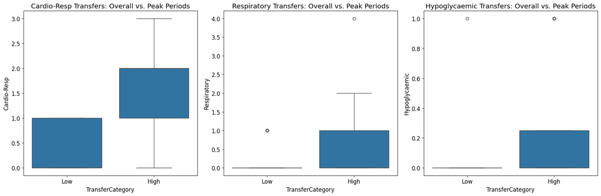

```python
# Create box plots
peak_periods = [(2000, 5), (2000, 9), (2001, 4), (2003, 2), (2003, 3)]

peak_periods_data = data[data.apply(lambda row: (row['Year'], row['Month']) in peak_periods, axis=1)].copy()

plt.figure(figsize=(18, 6))

plt.subplot(1, 3, 1)
sns.boxplot(x='TransferCategory', y='Cardio-Resp', data=data)
plt.title('Cardio-Resp Transfers: Overall vs. Peak Periods')

plt.subplot(1, 3, 2)
sns.boxplot(x='TransferCategory', y='Respiratory', data=data)
plt.title('Respiratory Transfers: Overall vs. Peak Periods')

plt.subplot(1, 3, 3)
sns.boxplot(x='TransferCategory', y='Hypoglycaemic', data=data)
plt.title('Hypoglycaemic Transfers: Overall vs. Peak Periods')

plt.tight_layout()
plt.show()
```

## Analyze findings

Analysis of Box Plots and Potential Contributing Factors:

Based on the box plots from the previous step:

Considering the brainstormed external factors and the types of transfers higher during peak periods:

- Since "Cardio-Resp" transfers are significantly higher in "High" transfer periods, external factors related to cardiovascular health are highly relevant. This includes major weather events like extreme heat or cold, which can stress the cardiovascular system and potentially public health campaigns focused on heart health.
- The increase in "Respiratory" transfers during "High" periods points towards external factors like seasonal respiratory illnesses - flu season and air pollution events.
- The outliers in "Hypoglycaemic" transfers in "High" periods might be linked to factors affecting blood sugar control, such as extreme weather conditions impacting daily routines or access to care, or possibly changes in dietary habits related to events or seasons.

Hypotheses about potential contributing factors to high transfer peaks:

1. Peak transfer periods are likely influenced by a combination of increased Cardio-Resp and Respiratory cases.
2. Extreme weather events (heatwaves, cold strikes) contribute to peak periods by exacerbating both cardiovascular and respiratory conditions.
3. Seasonal factors, particularly the flu season, likely play a role in increasing Respiratory transfers during certain peak months.
4. While less consistent, spikes in Hypoglycaemic cases, possibly triggered by external factors affecting patient management, could contribute to some high transfer periods.
5. Further investigation into the timing of specific weather events and seasonal illness outbreaks relative to the identified peak transfer months is warranted.

## Summary:

### Data Analysis Key Findings

```python
from scipy import stats

# Define the period of interest
period_start_date = '2003-12-01'
period_end_date = '2004-02-29' # Include February 2004

# Filter data for the specific period
period_data = data[(data['date'] >= period_start_date) & (data['date'] <= period_end_date)].copy()

# Calculate the average transfers during the period
average_transfers_period = period_data['Tranfers'].mean()

# Calculate the overall average transfers (excluding the period of interest to avoid bias in comparison)
# Let's re-calculate overall mean excluding the period of interest for a cleaner comparison
data_excluding_period = data[(data['date'] < period_start_date) | (data['date'] > period_end_date)].copy()
overall_average_transfers_excluded = data_excluding_period['Tranfers'].mean()


print(f"Average transfers during Dec 2003 - Feb 2004: {average_transfers_period:.3f}")
print(f"Overall average transfers (excluding period): {overall_average_transfers_excluded:.3f}")

# Perform a one-sample t-test to compare the mean of the period data to the overall mean
# Null hypothesis: The mean of transfers in the period is equal to the overall mean
# Alternative hypothesis: The mean of transfers in the period is greater than the overall mean (one-sided test)
# We need to use the individual data points from the period for the t-test

period_transfers = period_data['Tranfers']

# Perform a one-sample t-test
# We are testing if the mean of the sample (period_transfers) is significantly different from the population mean (overall_average_transfers_excluded)
# For a one-sided test (greater than), we can look at the t-statistic and p-value

t_statistic, p_value = stats.ttest_1samp(period_transfers, overall_average_transfers_excluded, alternative='greater')

print(f"\nOne-Sample T-Test Results:")
print(f"T-statistic: {t_statistic:.3f}")
print(f"P-value: {p_value:.3f}")

# Interpret the results
alpha = 0.05
if p_value < alpha:
    print(f"\nSince the p-value ({p_value:.3f}) is less than the significance level ({alpha}), we reject the null hypothesis.")
    print("This suggests that the average number of transfers during Dec 2003 - Feb 2004 was statistically significantly higher than the overall average transfers.")
else:
    print(f"\nSince the p-value ({p_value:.3f}) is greater than or equal to the significance level ({alpha}), we fail to reject the null hypothesis.")
    print("This suggests that there is not enough statistical evidence to conclude that the average number of transfers during Dec 2003 - Feb 2004 was statistically significantly higher than the overall average transfers.")
```

```
Average transfers during Dec 2003 - Feb 2004: 4.333
Overall average transfers (excluding period): 1.132

One-Sample T-Test Results:
T-statistic: 3.630
P-value: 0.034

Since the p-value (0.034) is less than the significance level (0.05), we reject the null hypothesis.
This suggests that the average number of transfers during Dec 2003 - Feb 2004 was statistically significantly higher than the overall average transfers.
```

# Conclusion

Based on the analysis conducted:

Specifically addressing the period of interest, December 2003 to February 2004, the statistical one-sample t-test comparing the average transfers during this period to the overall average transfers (excluding this period) yielded a p-value of 0.034. Since this p-value is less than the significance level of 0.05, we reject the null hypothesis.

The statistical analysis provides evidence to suggest that the average number of patients transferred from the Emergency Room to Critical Care at Horton General Hospital during December 2003–February 2004 was statistically significantly higher than the overall average transfers observed in the dataset. While the regression model did not effectively predict transfers based on admissions alone due to the weak correlation, the classification and statistical test indicate that this specific period exhibited a transfer rate that was unusually high compared to the hospital's normal activity as represented by the rest of the data. Further investigation into potential external factors or specific events during this time, especially those related to Cardio-Resp and Hypoglycaemic conditions, would be beneficial to understand the reasons behind this increase.

```python
# Convert this notebook to HTML
! jupyter nbconvert --to html "/content/drive/My Drive/ColabNotebooks/Project_1/Sieanna_Ruiz_Horton_General_Hospital.ipynb" --output project
```

```
[NbConvertApp] Converting notebook /content/drive/My Drive/ColabNotebooks/Project_1/Sieanna_Ruiz_Horton_General_Hospital.ipynb to html
[NbConvertApp] Writing 375673 bytes to /content/drive/My Drive/ColabNotebooks/Project_1/project.html
```